# Project 2 Data Science 220

## Our Team:

```
Liliana Inkpen: Processed, cleaned, and wrangling data into any needed formats. Helped create and mapped questions into queries on Pandas. Derived insights from query results.
Fiona Rubino: Found dataset and helped create each question to analyze. Wrote queries as Pandas to answer each question. Communicated insights as a text to share with others.
Nathan Pechulis: Worked on questions to analyze and data wrangling the data set.
Taryn McHugh: Began to work on Githubpages and general markdown prose. Helped with EDA and writing queries to generate answers.
```

## Our Dataset

**IMDb 2280 Most Voted Movies**: This tabular dataset consists of listings of all the movies and tv shows from IMDb, along with details such as - cast, directors, ratings, release year, duration, etc.

- **index** indexing the numbers in descending order from max votes to less
- **title:** title of movie/series
- **rtime:** runtime of movie/series
- **rating:** IMDB rating
- **votes:** number of votes it gets on IMDB
- **genre:** genre of movie/series separated by '|'
- **country:** countries in which Movie/Series got released, separated by '|'
- **releasedate:** date of release
- **filminglocation:** locations where it got shoot, separated by '|'
- **prodco:** production Companies, separated by '|'
- **years:** year in which it was released
- **director:** director of Movie/Series
- **writer:** writers of Movie/Series, separated by '|'
- **actors:** actors which performed in Movie/Series, separated by '|'
- **budget:** budget of Movie/Series
- **gross:** gross Income of Movie/Series

```python
import numpy as np
import pandas as pd
import matplotlib.pyplot as plt
IMDbData = pd.read_csv('IMDB_2280_Most_Voted_Movies.csv')
```

```python
plt
IMDbData = pd.read_csv('IMDB_2280_Most_Voted_Movies.csv')
```

```python
IMDbData.head()
```

|  | index | title | rtime | rating | votes | genre | country | releasedate | filminglocation | prodco | years | director | writer | actors | color | budget | gross | aspectratio | movielink |
| --- | --- | --- | --- | --- | --- | --- | --- | --- | --- | --- | --- | --- | --- | --- | --- | --- | --- | --- | --- |
| 0 | 1 | The Shawshank Redemption | 142min | 9.3 | 1853413 | Crime\|Drama | USA | 14October1994(USA) | St.Croix\|U.S.VirginIslands | CastleRockEntertainment | 1994.0 | FrankDarabont | StephenKing(shortstory"RitaHayworthandShawshan... | TimRobbins\|BobGunton\|ClancyBrown\|MarkRolston\|J... | Color(Technicolor) | $25000000 estimated | $28341469(USA) | 1.85:1 | http://www.imdb.com/title/tt0111161/?ref_=adv_... |
| 1 | 2 | The Dark Knight | 152min | 9.0 | 1832266 | Action\|Crime\|Drama | USA\|UK | 18July2008(India) | TimesSquare\|CausewayBay\|HongKong | WarnerBros.\|LegendaryEntertainment\|Syncopy | 2008.0 | ChristopherNolan | JonathanNolan(screenplay)\|ChristopherNolan(scr... | ChristianBale\|AaronEckhart\|MaggieGyllenhaal\|Mo... | Color(Technicolor) | $185000000 estimated | $533316061(USA)(27February2009) | 2.35:1 | http://www.imdb.com/title/tt0468569/?ref_=adv_... |
| 2 | 3 | Inception | 148min | 8.8 | 1622144 | Action\|Adventure\|Sci-Fi | USA\|UK | 16July2010(India) | Bedfordshire\|England\|UK | WarnerBros.\|LegendaryEntertainment\|Syncopy | 2010.0 | ChristopherNolan | NaN | LeonardoDiCaprio\|EllenPage\|KenWatanabe\|Cillian... | Color | $160000000 estimated | $292568851(USA)(31December2010) | 2.35:1 | http://www.imdb.com/title/tt1375666/?ref_=adv_... |
| 3 | 4 | Fight Club | 139min | 8.8 | 1485542 | Drama | USA\|Germany | 15October1999(USA) | 421W.EighthStreet\|LosAngeles\|California\|USA | Fox2000Pictures\|RegencyEnterprises\|LinsonFilms | 1999.0 | DavidFincher | ChuckPalahniuk(novel)\|JimUhls(screenplay) | EdwardNorton\|MeatLoaf\|RichmondArquette\|GeorgeM... | Color | $63000000 estimated | $37023395(USA)(25February2000) | 2.35:1 | http://www.imdb.com/title/tt0137523/?ref_=adv_... |
| 4 | 5 | Pulp Fiction | 154min | 8.9 | 1450538 | Crime\|Drama | USA | 14October1994(USA) | 1435FlowerStreet\|Glendale\|California\|USA | Miramax\|ABandApart\|JerseyFilms | 1994.0 | QuentinTarantino | QuentinTarantino(stories)\|RogerAvary(stories)\|... | TimRoth\|LauraLovelace\|SamuelL.Jackson\|FrankWha... | Color | $8000000 estimated | $107930000(USA) | 2.35:1 | http://www.imdb.com/title/tt0110912/?ref_=adv_... |

```python
IMDbData.columns
```

```
Index(['index', 'title', 'rtime', 'rating', 'votes', 'genre', 'country',
       'releasedate', 'filminglocation', 'prodco', 'years', 'director',
       'writer', 'actors', 'color', 'budget', 'gross', 'aspectratio',
       'movielink'],
      dtype='object')
```

# Data Cleaning

We are cleansing the data here by removing null values and duplicate entries

```python
IMDbData.isnull().sum()
```

```
index                0
title                0
rtime                0
rating               0
votes                0
genre                0
country             62
releasedate         62
filminglocation    155
prodco              62
years              208
director           208
writer             678
actors              62
color                6
budget             272
gross              332
aspectratio         65
movielink           60
dtype: int64
```

This is making sure we do not have any more duplicate values, meaning we do not have to remove anything else.

```python
IMDbData.dropna(subset = ['country','releasedate','filminglocation','prodco','years','director', 'writer', 'actors', 'color', 'budget', 'gross','aspectratio', 'movielink'], inplace=True)
IMDbData.isnull().sum()
```

```
index              0
title              0
rtime              0
rating             0
votes              0
genre              0
country            0
releasedate        0
filminglocation    0
prodco             0
years              0
director           0
writer             0
actors             0
color              0
budget             0
gross              0
aspectratio        0
movielink          0
dtype: int64
```

```python
IMDbData.duplicated().sum()
```

```
0
```

This is the data sorted in alphabetical order by movie title.

```python
IMDbData.sort_values('title', inplace = True)
IMDbData
```

|  | index | title | rtime | rating | votes | genre | country | releasedate | filminglocation | prodco | years | director | writer | actors | color | budget | gross | aspectratio | movielink |
| --- | --- | --- | --- | --- | --- | --- | --- | --- | --- | --- | --- | --- | --- | --- | --- | --- | --- | --- | --- |
| 227 | 228 | (500) Days of Summer | 95min | 7.7 | 406432 | Comedy\|Drama\|Romance | USA | 7August2009(USA) | BradburyBuilding-304S.Broadway\|Downtown\|LosAng... | FoxSearchlightPictures\|Watermark\|DuneEntertain... | 2009.0 | MarcWebb | ScottNeustadter\|MichaelH.Weber | JosephGordon-Levitt\|GeoffreyArend\|MatthewGrayG... | Color\|BlackandWhite(somesequences) | $7500000 estimated | $32391374(USA)(20November2009) | 2.35:1 | http://www.imdb.com/title/tt1022603/?ref_=adv_... |
| 1382 | 1383 | 10 000 BC | 109min | 5.1 | 113942 | Action\|Adventure\|Drama | USA\|SouthAfrica | 7March2008(India) | Namibia | WarnerBros.\|LegendaryEntertainment\|Centropolis... | 2008.0 | RolandEmmerich | RolandEmmerich\|HaraldKloser | StevenStrait\|CliffCurtis\|AffifBenBadra\|Nathana... | Color(Technicolor) | $105000000 estimated | $94770548(USA)(13June2008) | 2.35:1 | http://www.imdb.com/title/tt0443649/?ref_=adv_... |
| 672 | 673 | 10 Cloverfield Lane | 104min | 7.2 | 206131 | Drama\|Horror\|Mystery | USA | 11March2016(India) | NewOrleans\|Louisiana\|USA | ParamountPictures\|BadRobot\|SpectrumEffects | 2016.0 | DanTrachtenberg | JoshCampbell(screenplay)\|MatthewStuecken(scree... | JohnGoodman\|JohnGallagherJr.\|SuzanneCryer\|Suma... | Color | $15000000 estimated | $71897215(USA)(20May2016) | 2.35:1 | http://www.imdb.com/title/tt1179933/?ref_=adv_... |
| 525 | 526 | 10 Things I Hate About You | 97min | 7.2 | 243148 | Comedy\|Drama\|Romance | USA | 31March1999(USA) | 2715NorthJunettStreet\|Tacoma\|Washington\|USA | TouchstonePictures\|MadChance\|JaretEntertainment | 1999.0 | GilJunger | KarenMcCullah\|KirstenSmith | HeathLedger\|JosephGordon-Levitt\|DavidKrumholtz... | Color | $30000000 estimated | $38176108(USA)(27August1999) | 1.85:1 | http://www.imdb.com/title/tt0147800/?ref_=adv_... |
| 1920 | 1921 | 101 Dalmatians | 103min | 5.7 | 81542 | Adventure\|Comedy\|Crime | USA | 27November1996(USA) | KenwoodHouse\|HampsteadHeath\|Hampstead\|London\|E... | WaltDisneyPictures\|WizzerProductions\|GreatOaks... | 1996.0 | StephenHerek | DodieSmith(novel)\|JohnHughes(screenplay) | GlennClose\|JoelyRichardson\|HughLaurie\|JohnShra... | Color(Technicolor) | $75000000 estimated | $136182161(USA)(2May1997) | 2.35:1 | http://www.imdb.com/title/tt0115433/?ref_=adv_... |
| ... | ... | ... | ... | ... | ... | ... | ... | ... | ... | ... | ... | ... | ... | ... | ... | ... | ... | ... | ... |
| 2112 | 2113 | Zathura: A Space Adventure | 101min | 6.1 | 73953 | Action\|Adventure\|Comedy | USA | 11November2005(USA) | LosAngeles\|California\|USA | ColumbiaPicturesCorporation\|RadarPictures\|Teit... | 2005.0 | JonFavreau | ChrisVanAllsburg(book)\|DavidKoepp(screenplay)\|... | JonahBobo\|DaxShepard\|TimRobbins\|JohnAlexander\|... | Color | $65000000 estimated | $28045540(USA)(9December2005) | 1.85:1 | http://www.imdb.com/title/tt0406375/?ref_=adv_... |
| 310 | 311 | Zodiac | 157min | 7.7 | 341011 | Crime\|Drama\|History | USA | 20July2007(India) | TheEarlWarrenBuilding\|346McAllisterStSanFranci... | ParamountPictures\|WarnerBros.\|PhoenixPictures | 2007.0 | DavidFincher | JamesVanderbilt(screenplay)\|RobertGraysmith(book) | JakeGyllenhaal\|AnthonyEdwards\|BrianCox\|Richmon... | Color | $65000000 estimated | $33048353(USA)(27April2007) | 2.35:1 | http://www.imdb.com/title/tt0443706/?ref_=adv_... |
| 213 | 214 | Zombieland | 88min | 7.7 | 417637 | Adventure\|Comedy\|Horror | USA | 19February2010(India) | OneParkPlaceB5\|Atlanta\|Georgia\|USA | ColumbiaPictures\|RelativityMedia\|Pariah | 2009.0 | RubenFleischer | RhettReese\|PaulWernick | JesseEisenberg\|EmmaStone\|AmberHeard\|DerekGraf\|... | Color | $23600000 estimated | $75590286(USA)(11December2009) | 2.35:1 | http://www.imdb.com/title/tt1156398/?ref_=adv_... |
| 626 | 627 | Zoolander | 90min | 6.6 | 214622 | Comedy | Germany\|USA | 28September2001(USA) | CornerofN.MooreSt.W.Broadway\|NewYorkCity\|NewYo... | ParamountPictures\|VillageRoadshowPictures\|VH1T... | 2001.0 | BenStiller | DrakeSather(characterDerekZoolander)\|BenStille... | BenStiller\|ChristineTaylor\|MillaJovovich\|David... | Color | $28000000 estimated | $45162741(USA)(4January2002) | 2.35:1 | http://www.imdb.com/title/tt0196229/?ref_=adv_... |
| 1377 | 1378 | Æon Flux | 93min | 5.5 | 114278 | Action\|Sci-Fi | USA | 2December2005(USA) | Germany | ParamountPictures\|LakeshoreEntertainment\|Valha... | 2005.0 | KarynKusama | PhilHay\|MattManfredi\|1morecredit | CharlizeTheron\|JonnyLeeMiller\|FrancesMcDormand... | Color | $62000000 estimated | $25857987(USA)(3February2006) | 2.35:1 | http://www.imdb.com/title/tt0402022/?ref_=adv_... |

1396 rows × 19 columns

```python
CleanedIMDbData = IMDbData.iloc[:,[0,1,2,3,4,5,6,7,8,9,10,11,12,13,14,15]]
CleanedIMDbData
```

|  | index | title | rtime | rating | votes | genre | country | releasedate | filminglocation | prodco | years | director | writer | actors | color | budget |
| --- | --- | --- | --- | --- | --- | --- | --- | --- | --- | --- | --- | --- | --- | --- | --- | --- |
| 227 | 228 | (500) Days of Summer | 95min | 7.7 | 406432 | Comedy\|Drama\|Romance | USA | 7August2009(USA) | BradburyBuilding-304S.Broadway\|Downtown\|LosAng... | FoxSearchlightPictures\|Watermark\|DuneEntertain... | 2009.0 | MarcWebb | ScottNeustadter\|MichaelH.Weber | JosephGordon-Levitt\|GeoffreyArend\|MatthewGrayG... | Color\|BlackandWhite(somesequences) | $7500000 estimated |
| 1382 | 1383 | 10 000 BC | 109min | 5.1 | 113942 | Action\|Adventure\|Drama | USA\|SouthAfrica | 7March2008(India) | Namibia | WarnerBros.\|LegendaryEntertainment\|Centropolis... | 2008.0 | RolandEmmerich | RolandEmmerich\|HaraldKloser | StevenStrait\|CliffCurtis\|AffifBenBadra\|Nathana... | Color(Technicolor) | $105000000 estimated |
| 672 | 673 | 10 Cloverfield Lane | 104min | 7.2 | 206131 | Drama\|Horror\|Mystery | USA | 11March2016(India) | NewOrleans\|Louisiana\|USA | ParamountPictures\|BadRobot\|SpectrumEffects | 2016.0 | DanTrachtenberg | JoshCampbell(screenplay)\|MatthewStuecken(scree... | JohnGoodman\|JohnGallagherJr.\|SuzanneCryer\|Suma... | Color | $15000000 estimated |
| 525 | 526 | 10 Things I Hate About You | 97min | 7.2 | 243148 | Comedy\|Drama\|Romance | USA | 31March1999(USA) | 2715NorthJunettStreet\|Tacoma\|Washington\|USA | TouchstonePictures\|MadChance\|JaretEntertainment | 1999.0 | GilJunger | KarenMcCullah\|KirstenSmith | HeathLedger\|JosephGordon-Levitt\|DavidKrumholtz... | Color | $30000000 estimated |
| 1920 | 1921 | 101 Dalmatians | 103min | 5.7 | 81542 | Adventure\|Comedy\|Crime | USA | 27November1996(USA) | KenwoodHouse\|HampsteadHeath\|Hampstead\|London\|E... | WaltDisneyPictures\|WizzerProductions\|GreatOaks... | 1996.0 | StephenHerek | DodieSmith(novel)\|JohnHughes(screenplay) | GlennClose\|JoelyRichardson\|HughLaurie\|JohnShra... | Color(Technicolor) | $75000000 estimated |
| ... | ... | ... | ... | ... | ... | ... | ... | ... | ... | ... | ... | ... | ... | ... | ... | ... |
| 2112 | 2113 | Zathura: A Space Adventure | 101min | 6.1 | 73953 | Action\|Adventure\|Comedy | USA | 11November2005(USA) | LosAngeles\|California\|USA | ColumbiaPicturesCorporation\|RadarPictures\|Teit... | 2005.0 | JonFavreau | ChrisVanAllsburg(book)\|DavidKoepp(screenplay)\|... | JonahBobo\|DaxShepard\|TimRobbins\|JohnAlexander\|... | Color | $65000000 estimated |
| 310 | 311 | Zodiac | 157min | 7.7 | 341011 | Crime\|Drama\|History | USA | 20July2007(India) | TheEarlWarrenBuilding\|346McAllisterStSanFranci... | ParamountPictures\|WarnerBros.\|PhoenixPictures | 2007.0 | DavidFincher | JamesVanderbilt(screenplay)\|RobertGraysmith(book) | JakeGyllenhaal\|AnthonyEdwards\|BrianCox\|Richmon... | Color | $65000000 estimated |
| 213 | 214 | Zombieland | 88min | 7.7 | 417637 | Adventure\|Comedy\|Horror | USA | 19February2010(India) | OneParkPlaceB5\|Atlanta\|Georgia\|USA | ColumbiaPictures\|RelativityMedia\|Pariah | 2009.0 | RubenFleischer | RhettReese\|PaulWernick | JesseEisenberg\|EmmaStone\|AmberHeard\|DerekGraf\|... | Color | $23600000 estimated |
| 626 | 627 | Zoolander | 90min | 6.6 | 214622 | Comedy | Germany\|USA | 28September2001(USA) | CornerofN.MooreSt.W.Broadway\|NewYorkCity\|NewYo... | ParamountPictures\|VillageRoadshowPictures\|VH1T... | 2001.0 | BenStiller | DrakeSather(characterDerekZoolander)\|BenStille... | BenStiller\|ChristineTaylor\|MillaJovovich\|David... | Color | $28000000 estimated |
| 1377 | 1378 | Æon Flux | 93min | 5.5 | 114278 | Action\|Sci-Fi | USA | 2December2005(USA) | Germany | ParamountPictures\|LakeshoreEntertainment\|Valha... | 2005.0 | KarynKusama | PhilHay\|MattManfredi\|1morecredit | CharlizeTheron\|JonnyLeeMiller\|FrancesMcDormand... | Color | $62000000 estimated |

1396 rows × 16 columns

# Exploratory Data Analysis and Data Visualization

For EDA we just wanted to see if we can find any fun relationships and interesting things within the data. The EDA was purely for observation and to see what we could find out about the data. The first type of EDA done was a histogram of year.

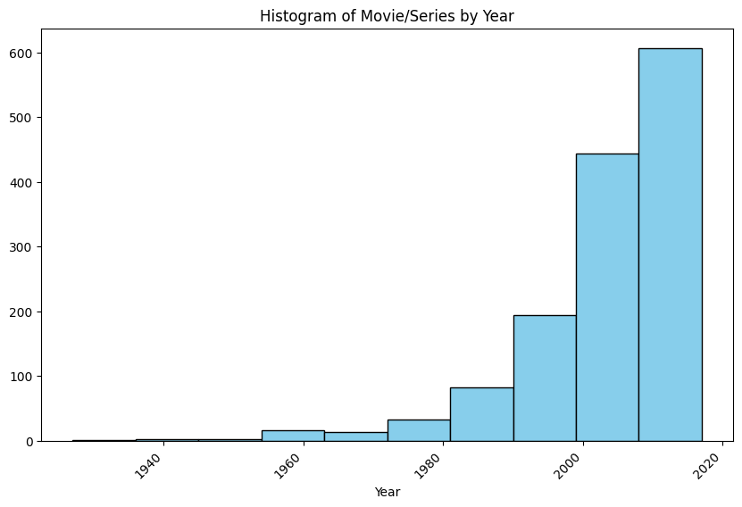

```python
EDA = CleanedIMDbData.copy()
plt.figure(figsize=(10, 6))
plt.hist(EDA["years"], color= "skyblue", edgecolor = "black")
plt.xticks(rotation=45, ha= "right")
plt.xlabel("Year")
plt.ylabel('')
plt.title('Histogram of Movie/Series by Year')
plt.show()
```

Next we wanted to see if we could find any relationships between numerical values in the data set. We created a correlation matrix of the numerical components of the dataset.

```python
# split time
timeMin=[]
for line in EDA['rtime']:
  if 'm' in line:
    templist=line.split('m')
    timeMin+=[templist[0]]
  else:
    templist = [line]
    timeMin+=templist
EDA['timeMin'] = timeMin

#split budget
budgetMon=[]
for line in EDA['budget']:
  if '$' in line:
    templist=line.split('$')
    budgetMon+=[templist[1]]
  else:
    templist = [line]
    budgetMon+=templist
EDA['temp'] = budgetMon

budgetMon=[]
for line in EDA['temp']:
  if ' ' in line:
    templist=line.split(' ')
    budgetMon+=[templist[0]]
  else:
    templist = [line]
    budgetMon+=templist
EDA['budgetMon'] = budgetMon

EDA['budgetMon'] = pd.to_numeric(EDA['budgetMon'], errors='coerce')
EDA = EDA[["budgetMon", "years", "rating", "votes", "timeMin"]]
EDA.corr()
```

|  | budgetMon | years | rating | votes | timeMin |
| --- | --- | --- | --- | --- | --- |
| budgetMon | 1.000000 | 0.343222 | -0.152936 | 0.260350 | 0.254959 |
| years | 0.343222 | 1.000000 | -0.294982 | 0.000862 | -0.095213 |
| rating | -0.152936 | -0.294982 | 1.000000 | 0.514055 | 0.391883 |
| votes | 0.260350 | 0.000862 | 0.514055 | 1.000000 | 0.336098 |
| timeMin | 0.254959 | -0.095213 | 0.391883 | 0.336098 | 1.000000 |

# Questions

## Question 1: Display all movies that were released in the year 2006 and only in the United States.

```python
D = CleanedIMDbData.loc[CleanedIMDbData["releasedate"].str.contains("2006")]
D = D.loc[CleanedIMDbData["country"] == "USA"]
D[['title','genre','country','releasedate']]
```

|  | title | genre | country | releasedate |
| --- | --- | --- | --- | --- |
| 1668 | A Scanner Darkly | Animation\|Crime\|Drama | USA | 28July2006(USA) |
| 1416 | Accepted | Comedy | USA | 18August2006(USA) |
| 510 | Apocalypto | Action\|Adventure\|Drama | USA | 8December2006(USA) |
| 403 | Cars | Animation\|Comedy\|Family | USA | 4August2006(India) |
| 468 | Click | Comedy\|Drama\|Fantasy | USA | 23June2006(USA) |
| 662 | Crank | Action\|Crime\|Thriller | USA | 1September2006(USA) |
| 1478 | Flags of Our Fathers | Drama\|History\|War | USA | 20October2006(USA) |
| 2089 | Half Nelson | Drama | USA | 22September2006(USA) |
| 1994 | Monster House | Animation\|Adventure\|Comedy | USA | 21July2006(USA) |
| 2191 | Open Season | Animation\|Adventure\|Comedy | USA | 29September2006(USA) |
| 1151 | Over the Hedge | Animation\|Adventure\|Comedy | USA | 19May2006(USA) |
| 107 | Pirates of the Caribbean: Dead Man's Chest | Action\|Adventure\|Fantasy | USA | 7July2006(USA) |
| 1814 | Poseidon | Action\|Adventure\|Drama | USA | 12May2006(India) |
| 851 | Rocky Balboa | Drama\|Sport | USA | 20December2006(USA) |
| 1576 | Scary Movie 4 | Comedy\|Horror | USA | 14April2006(USA) |
| 1606 | Step Up | Crime\|Drama\|Music | USA | 11August2006(USA) |
| 516 | Superman Returns | Action\|Adventure\|Sci-Fi | USA | 30June2006(India) |
| 1120 | Talladega Nights: The Ballad of Ricky Bobby | Action\|Comedy\|Sport | USA | 4August2006(USA) |
| 716 | Thank You for Smoking | Comedy\|Drama | USA | 14April2006(USA) |
| 1450 | The Break-Up | Comedy\|Drama\|Romance | USA | 2June2006(USA) |
| 1136 | The Hills Have Eyes | Horror | USA | 10March2006(USA) |
| 1295 | The Lake House | Drama\|Fantasy\|Romance | USA | 16June2006(USA) |
| 2205 | World Trade Center | Drama\|History\|Thriller | USA | 9August2006(USA) |

```python
len(D.index)
```

```
23
```

## Question 2: How many of the movies from above were Adam Sandler in?

```python
D = D.loc[D["actors"].str.contains("AdamSandler")]
D
```

|  | index | title | rtime | rating | votes | genre | country | releasedate | filminglocation | prodco | years | director | writer | actors | color | budget |
| --- | --- | --- | --- | --- | --- | --- | --- | --- | --- | --- | --- | --- | --- | --- | --- | --- |
| 468 | 469 | Click | 107min | 6.4 | 263065 | Comedy\|Drama\|Fantasy | USA | 23June2006(USA) | BrooklynBridge\|NewYorkCity\|NewYork\|USA | ColumbiaPicturesCorporation\|RevolutionStudios\|... | 2006.0 | FrankCoraci | SteveKoren\|MarkO'Keefe | AdamSandler\|ChristopherWalken\|HenryWinkler\|Sea... | Color | $70000000 estimated |

```python
D["index"].count()
```

```
1
```

One of our favorite actors is Adam Sandler (love Hubie Halloween). So going off the last question, of the movies released in 2006 in the USA, Adam Sandler is only in one of them and that is the movie 'Click.'

## Question 3: Find the number average rating for each genre.

```python
MainGenre=[]
for line in CleanedIMDbData['genre']:
  if '|' in line:
    templist=line.split('|')
    MainGenre+=[templist[0]]
  else:
    templist = [line]
    MainGenre+=templist

CleanedIMDbData = CleanedIMDbData.copy()
CleanedIMDbData.loc[:, 'MainGenre'] = MainGenre
CleanedIMDbData[['title', 'genre', 'MainGenre', 'rating']]
```

|  | title | genre | MainGenre | rating |
| --- | --- | --- | --- | --- |
| 227 | (500) Days of Summer | Comedy\|Drama\|Romance | Comedy | 7.7 |
| 1382 | 10 000 BC | Action\|Adventure\|Drama | Action | 5.1 |
| 672 | 10 Cloverfield Lane | Drama\|Horror\|Mystery | Drama | 7.2 |
| 525 | 10 Things I Hate About You | Comedy\|Drama\|Romance | Comedy | 7.2 |
| 1920 | 101 Dalmatians | Adventure\|Comedy\|Crime | Adventure | 5.7 |
| ... | ... | ... | ... | ... |
| 2112 | Zathura: A Space Adventure | Action\|Adventure\|Comedy | Action | 6.1 |
| 310 | Zodiac | Crime\|Drama\|History | Crime | 7.7 |
| 213 | Zombieland | Adventure\|Comedy\|Horror | Adventure | 7.7 |
| 626 | Zoolander | Comedy | Comedy | 6.6 |
| 1377 | Æon Flux | Action\|Sci-Fi | Action | 5.5 |

1396 rows × 4 columns

For question 3, we wanted to see differences in rating based on genre. The issue that we ran into was the the genre column has multiple genres that were split by a |. In the code above we had to create a column titled MainGenre where we took the first genre of each title and placed it into that column.

```python
AverageRatings = CleanedIMDbData.groupby('MainGenre')['rating'].mean()
AverageRatings = AverageRatings.reset_index()
AverageRatings = AverageRatings.sort_values(by='rating', ascending=False)
AverageRatings
```

|  | MainGenre | rating |
| --- | --- | --- |
| 14 | Western | 8.450000 |
| 3 | Biography | 7.592405 |
| 11 | Mystery | 7.550000 |
| 5 | Crime | 7.490196 |
| 7 | Family | 7.400000 |
| 6 | Drama | 7.297000 |
| 2 | Animation | 7.223636 |
| 10 | Musical | 7.200000 |
| 13 | Sci-Fi | 7.128571 |
| 12 | Romance | 7.100000 |
| 1 | Adventure | 7.082258 |
| 8 | Fantasy | 6.933333 |
| 0 | Action | 6.656212 |
| 4 | Comedy | 6.650193 |
| 9 | Horror | 6.420339 |

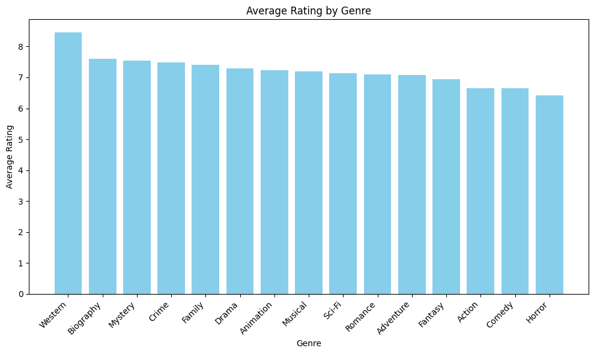

```python
plt.figure(figsize=(10, 6))
plt.bar(AverageRatings['MainGenre'], AverageRatings['rating'], color='skyblue')
plt.xticks(rotation=45, ha='right')
plt.xlabel('Genre')
plt.ylabel('Average Rating')
plt.title('Average Rating by Genre')
plt.tight_layout()
plt.show()
```

## Question 4: What are the 10 highest rated comedy movies?

```python
ComMovies = CleanedIMDbData.loc[CleanedIMDbData["genre"] == "Comedy"]
ComMovies = ComMovies.sort_values("rating", ascending=False)
ComMovies = ComMovies[['title','genre','rating', 'votes','releasedate']]
ComMovies.head(10)
```

|  | title | genre | rating | votes | releasedate |
| --- | --- | --- | --- | --- | --- |
| 392 | Life of Brian | Comedy | 8.1 | 295437 | 8November1979(UK) |
| 1269 | Young Frankenstein | Comedy | 8.0 | 123076 | 15December1974(USA) |
| 857 | Airplane! | Comedy | 7.8 | 173037 | 2July1980(USA) |
| 638 | Office Space | Comedy | 7.8 | 212044 | 19February1999(USA) |
| 83 | The Hangover | Comedy | 7.8 | 621033 | 26June2009(India) |
| 1626 | Animal House | Comedy | 7.6 | 95976 | 28July1978(USA) |
| 185 | Superbad | Comedy | 7.6 | 449400 | 26October2007(India) |
| 1415 | Trading Places | Comedy | 7.5 | 110888 | 8June1983(USA) |
| 747 | Old School | Comedy | 7.2 | 193500 | 21February2003(USA) |
| 415 | Anchorman: The Legend of Ron Burgundy | Comedy | 7.2 | 285358 | 9July2004(USA) |

One of our favorite genres is comedy (hence us loving Adam Sandler), so we wanted to take what we put together in the last section and apply it to this question. We filtered the data to make sure the genre was comedy, sorted them by rating (highest to lowest), and displayed the top ten. The top ten comedy movies are "Life of Brian", "Young Frankenstein", "Airplane!", "Office Space", "The Hangover", "Animal House", "Superbad", "Trading Places", "Old School", and "Anchorman: The Legend of Ron Burgundy." These are released in any year, in any county, but rated on IMDb.

## Question 5: What are the 10 lowest rated horror movies?

```python
HorMovies = CleanedIMDbData.loc[CleanedIMDbData["genre"] == "Horror"]
HorMovies = HorMovies.sort_values("rating", ascending=False)
HorMovies = HorMovies[['title','genre','rating','votes', 'releasedate']]
HorMovies.tail(10)
```

|  | title | genre | rating | votes | releasedate |
| --- | --- | --- | --- | --- | --- |
| 1136 | The Hills Have Eyes | Horror | 6.4 | 138619 | 10March2006(USA) |
| 1026 | Saw III | Horror | 6.2 | 151704 | 27October2006(USA) |
| 1373 | The Texas Chainsaw Massacre | Horror | 6.2 | 114518 | 17October2003(USA) |
| 1693 | Halloween | Horror | 6.1 | 93186 | 31August2007(USA) |
| 1946 | Paranormal Activity 3 | Horror | 5.8 | 80654 | 21October2011(India) |
| 1799 | Paranormal Activity 2 | Horror | 5.7 | 86917 | 3December2010(India) |
| 1958 | Friday the 13th | Horror | 5.6 | 80212 | 8May2009(India) |
| 2235 | Thir13en Ghosts | Horror | 5.6 | 68944 | 26October2001(USA) |
| 1957 | Ghost Ship | Horror | 5.5 | 80267 | 25October2002(USA) |
| 1562 | House of Wax | Horror | 5.3 | 100006 | 6May2005(USA) |

Like our last question, we wanted to take what we did in a previous question and apply it. One of our least favorite genres is horror (too scary)! Again, we filtered the data to make sure the genre was horror, sorted them by rating (best to worst), and displayed the bottom ten. Now I know what movies to definitely stay away from. The bottom ten horror movies are "The Hills Have Eyes", "Saws III", "The Texas Chainsaw Massacre", "Halloween", "Paranormal Activity 3", "Paranormal Activity 2", "Friday the 13th", "Thir13en Ghosts", "Ghost Ship", and "House of Wax." These are released in any year, in any county, but rated on IMDb.

## Question 6: Which movie director had the highest total run time in minutes?

```python
MainDirector=[]
for line in CleanedIMDbData['director']:
  if '|' in line:
    templist=line.split('|')
    MainDirector+=[templist[0]]
  else:
    templist = [line]
    MainDirector+=templist

EDA.loc[:, 'MainDirector'] =MainDirector
EDA['timeMin'] = pd.to_numeric(EDA['timeMin'], errors='coerce')
AverageScreen = EDA.groupby('MainDirector')['timeMin'].sum()
AverageScreen = AverageScreen.reset_index()
AverageScreen=AverageScreen.sort_values(by='timeMin', ascending=False)
AverageScreen.head(1)
```

|  | MainDirector | timeMin |
| --- | --- | --- |
| 601 | StevenSpielberg | 2480 |

## Question 7: What countries have the most movies/series produced?

```python
MainCountry=[]
for line in CleanedIMDbData['country']:
  if '|' in line:
    templist=line.split('|')
    MainCountry+=[templist[0]]
  else:
    templist = [line]
    MainCountry+=templist

CleanedIMDbData = CleanedIMDbData.copy()
CleanedIMDbData['MainCountry'] = MainCountry
split_data = CleanedIMDbData.explode('MainCountry')
countries = split_data.groupby('MainCountry').size().reset_index(name='movieCount')
sortedCountry = countries.sort_values(by='movieCount', ascending=False)
sortedCountry.head(10)
```

|  | MainCountry | movieCount |
| --- | --- | --- |
| 26 | USA | 1114 |
| 25 | UK | 132 |
| 7 | France | 36 |
| 8 | Germany | 26 |
| 3 | Canada | 13 |
| 1 | Australia | 13 |
| 4 | China | 9 |
| 13 | Italy | 7 |
| 22 | Spain | 5 |
| 17 | NewZealand | 5 |

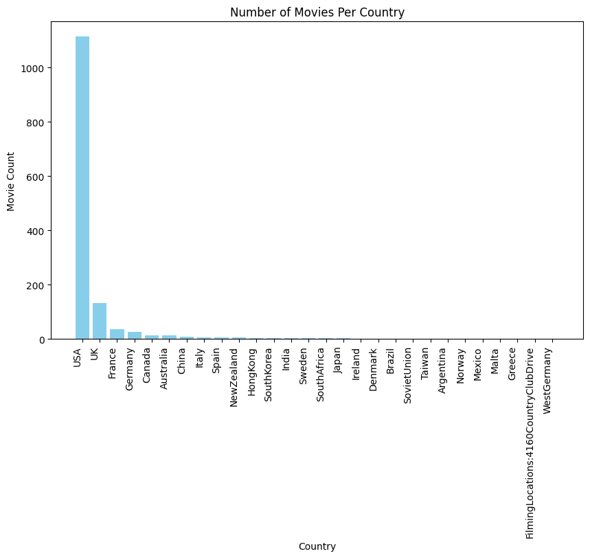

```python
plt.figure(figsize=(10, 6))
plt.bar(sortedCountry['MainCountry'], sortedCountry['movieCount'], color='skyblue')
plt.xticks(rotation=90, ha='right')
plt.xlabel('Country')
plt.ylabel('Movie Count')
plt.title('Number of Movies Per Country')
plt.show()
```

To help enhance our results we plotted it. This really shows how much the top couple countries are ahead of others in producing movies/series.

## Question 8: What year had the highest total budget for movies?

```python
EDA['budgetMon'] = pd.to_numeric(EDA['budgetMon'], errors = "coerce")
TotalBudget=EDA.groupby('years')['budgetMon'].sum().reset_index()
TotalBudget=TotalBudget.sort_values(by='budgetMon', ascending=True)
TotalBudget.tail(10)
```

|  | years | budgetMon |
| --- | --- | --- |
| 53 | 2006.0 | 3.647300e+09 |
| 62 | 2015.0 | 4.152926e+09 |
| 55 | 2008.0 | 4.157800e+09 |
| 57 | 2010.0 | 4.185300e+09 |
| 54 | 2007.0 | 4.318500e+09 |
| 63 | 2016.0 | 4.402800e+09 |
| 61 | 2014.0 | 4.496400e+09 |
| 59 | 2012.0 | 4.611100e+09 |
| 58 | 2011.0 | 4.975100e+09 |
| 60 | 2013.0 | 5.621000e+09 |

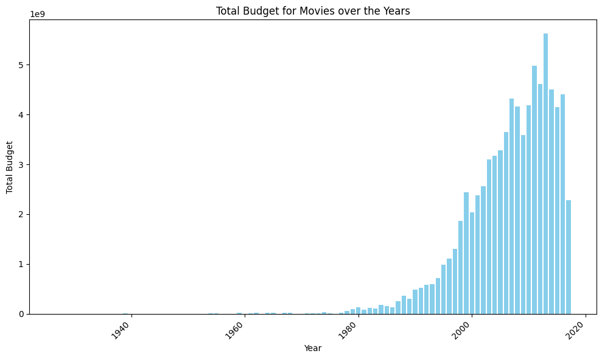

```python
plt.figure(figsize=(10, 6))
plt.bar(TotalBudget['years'], TotalBudget['budgetMon'], color='skyblue')
plt.xticks(rotation=45, ha='right')
plt.xlabel('Year')
plt.ylabel('Total Budget')
plt.title('Total Budget for Movies over the Years')
plt.tight_layout()
plt.show()
```

To help visualize the budget over the year, we also plotted it on a bar chart. You can see the very obvious increase in budget for the year of 2013.

## Question 9: How does a movie's run time compare to its rating?

```python
EDA[['timeMin','rating']]
```

|  | timeMin | rating |
| --- | --- | --- |
| 227 | 95 | 7.7 |
| 1382 | 109 | 5.1 |
| 672 | 104 | 7.2 |
| 525 | 97 | 7.2 |
| 1920 | 103 | 5.7 |
| ... | ... | ... |
| 2112 | 101 | 6.1 |
| 310 | 157 | 7.7 |
| 213 | 88 | 7.7 |
| 626 | 90 | 6.6 |
| 1377 | 93 | 5.5 |

1396 rows × 2 columns

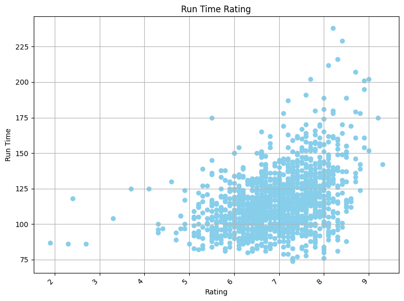

```python
plt.figure(figsize=(8, 6))
plt.scatter(EDA['rating'], EDA['timeMin'], color="skyblue", marker='o')
plt.xticks(rotation=45, ha='right')
plt.xlabel('Rating')
plt.ylabel('Run Time')
plt.title('Run Time Rating')
plt.grid(True)
plt.tight_layout()
plt.show()
```

# Conclusions

We performed a complete data analysis on our IMDb dataset step by step. We imported the data into the DataFrame, explored the nature of data, and cleaned the data. We then performed simple EDA to see if we can find interest or unique relationships in the finally. We then manipulated the data for some of the questions so that we could answer the question that was posed. After, we mapped our questions as queries on the Pandas dataframe to answer our questions. For some questions, we created a visualization to represent the question and result. After we wrote and executed queries for each question, we wrote a detailed analysis beneath each. Finally we published our work on Github Pages.